# STATS 60 Rlab Session 2

Yuchen Wu

2020/7/1

## Project proposal

- 1-2 paragraphs long
- Details on the problem you wish to explore, datasets you will use, potential visualizations
- Due **July 15 (Wed), 5PM Pacific Time**

## Agenda for today

- Introduction to data frame
- Different kinds of plots
- Plotting with `ggplot2` (and the `+` syntax)

## Lists

In all the data structures so far, the elements have to be of the same type. To have elements on different types in one data structure, we can use a list, which we create with `list()`. We can think of a list as a collection of key-value pairs. Keys should be strings.

```r
person <- list(name = "John Doe", age = 26)
person
```

```
## $name
## [1] "John Doe"
##
## $age
## [1] 26
```

## Lists

The `str` function can be used to inspect what is inside `person`:

```r
str(person)
```

```
## List of 2
##  $ name: chr "John Doe"
##  $ age : num 26
```

To access the `name` element `person`, we have 2 options:

```r
person[["name"]]
```

```
## [1] "John Doe"
```

```r
person$name
```

```
## [1] "John Doe"
```

## Lists

The elements of a list can be anything, even another data structure! Let’s add the names of John’s children to the `person` object:

```r
person$children <- c("Ross", "Robert")
str(person)
```

```
## List of 3
##  $ name    : chr "John Doe"
##  $ age     : num 26
##  $ children: chr [1:2] "Ross" "Robert"
```

To see the keys associated with a list, use the `names()` function:

```r
names(person)
```

```
## [1] "name"     "age"      "children"
```

## What is a data frame?

- A **data frame** is R’s data structure for storing datasets
  - First row: variable/covariate/feature names
  - Each subsequent row represents one observation
  - Each column contains the values of that variable across observations

A special type of list:

- list keys are variable names of the dataset
- list values are all vectors of the same length (no. of observations)

## Data frame

```r
data(mtcars)
str(mtcars)
```

```
## 'data.frame':    32 obs. of  11 variables:
##  $ mpg : num  21 21 22.8 21.4 18.7 18.1 14.3 24.4 22.8 19.2 ...
##  $ cyl : num  6 6 4 6 8 6 8 4 4 6 ...
##  $ disp: num  160 160 108 258 360 ...
##  $ hp  : num  110 110 93 110 175 105 245 62 95 123 ...
##  $ drat: num  3.9 3.9 3.85 3.08 3.15 2.76 3.21 3.69 3.92 3.92 ...
##  $ wt  : num  2.62 2.88 2.32 3.21 3.44 ...
##  $ qsec: num  16.5 17 18.6 19.4 17 ...
##  $ vs  : num  0 0 1 1 0 1 0 1 1 1 ...
##  $ am  : num  1 1 1 0 0 0 0 0 0 0 ...
##  $ gear: num  4 4 4 3 3 3 3 4 4 4 ...
##  $ carb: num  4 4 1 1 2 1 4 2 2 4 ...
```

## Data Frame

We can use “help” menu on the bottom right corner of the Rstudio to check for the meaning of the variable names:

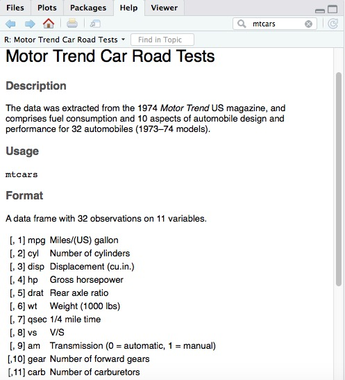

## Data Frame

```r
View(mtcars)
```

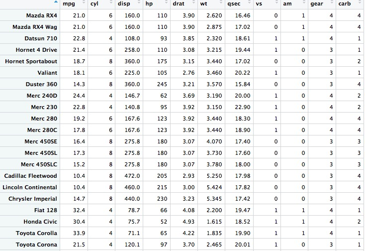

## Data Frame

```r
head(mtcars)     ## return the first 6 rows of the data set, also works with "tail"
```

```
##                    mpg cyl disp  hp drat    wt  qsec vs am gear carb
## Mazda RX4         21.0   6  160 110 3.90 2.620 16.46  0  1    4    4
## Mazda RX4 Wag     21.0   6  160 110 3.90 2.875 17.02  0  1    4    4
## Datsun 710        22.8   4  108  93 3.85 2.320 18.61  1  1    4    1
## Hornet 4 Drive    21.4   6  258 110 3.08 3.215 19.44  1  0    3    1
## Hornet Sportabout 18.7   8  360 175 3.15 3.440 17.02  0  0    3    2
## Valiant           18.1   6  225 105 2.76 3.460 20.22  1  0    3    1
```

```r
names(mtcars)
```

```
##  [1] "mpg"  "cyl"  "disp" "hp"   "drat" "wt"   "qsec" "vs"   "am"   "gear"
## [11] "carb"
```

```r
dim(mtcars)
```

```
## [1] 32 11
```

## Data Frame

Instead of using built-in data sets, we can also let R read from local files

```r
# First, set your working directory
setwd("~/Desktop/")
carSpeeds <- read.csv(file = 'data/car-speeds.csv')
```

Can also read data from website!

```r
df <- read.csv("https://stats60.github.io/Rlab/worldbank_data_tidy.csv",
               stringsAsFactors = FALSE)
```

## Words vs. pictures

*“The simple graph has brought more information to the data analyst’s mind than any other device.”* - John Tukey

```r
library(ggplot2)
p_base <- ggplot(data = df, mapping = aes(y = mpg, x = weight))
p_scatter <- p_base + geom_point(aes(col = cylinders), size = 2)
p_scatter
```

[output not shown]

## Two classes of variables in statistics

- **Continuous variable**: Variable takes on values which fall on the real number line (or part of it)
  - E.g. height, exam score, attendance count
- **Categorical variable**: Variable takes on values which fall into discrete categories
  - E.g. ice-cream flavor, country of origin

## Barplots: counts for a categorical variable

*What is the distribution of cylinders in my dataset?*

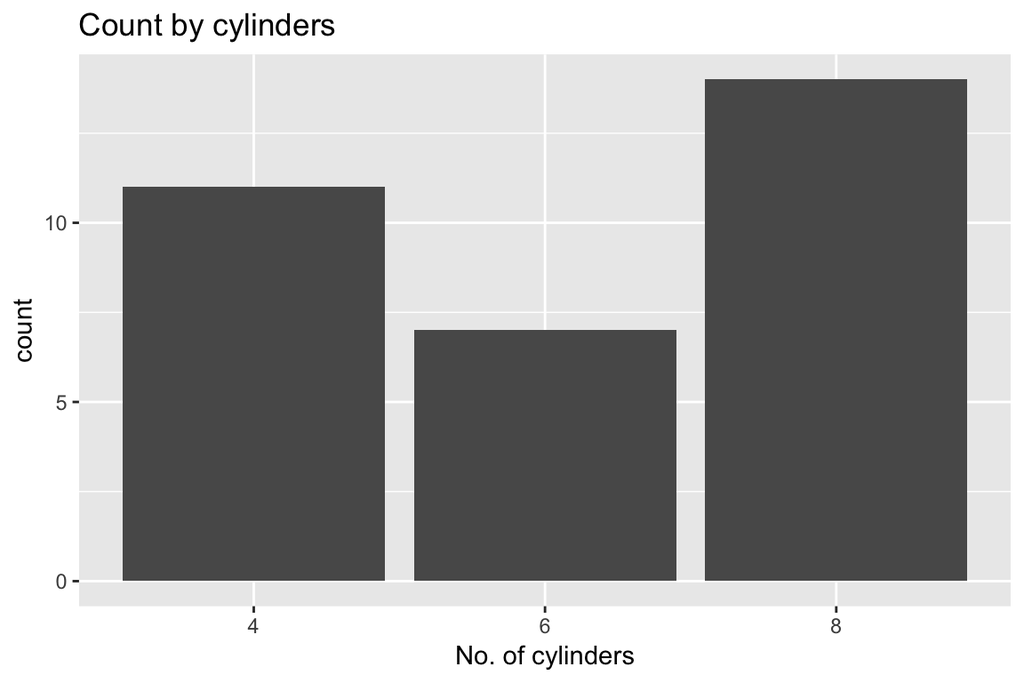

```r
ggplot(data = mtcars) +
    geom_bar(aes(x = factor(cyl))) +
    ggtitle("Count by cylinders") +
    xlab("No. of cylinders")
```

## Histograms: counts for a continuous variable

*What is the distribution of `miles per gallon` in my dataset?*

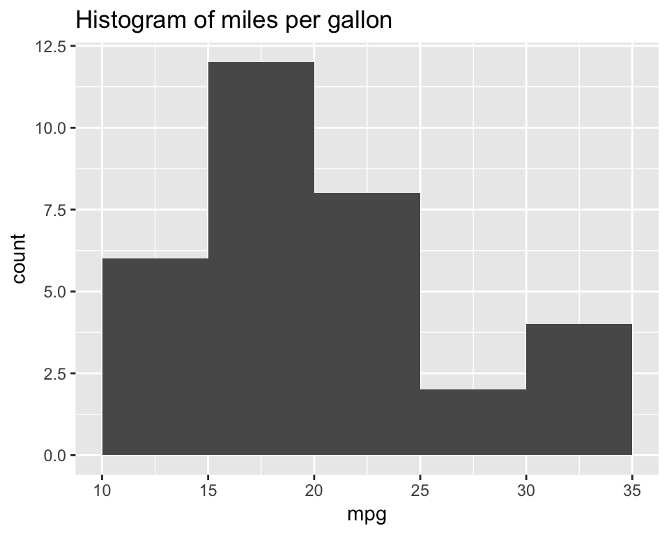

```r
p_hist <- ggplot(data = mtcars) +
    geom_histogram(aes(x = mpg), breaks = seq(10, 35, 5)) +
    ggtitle("Histogram of miles per gallon")
p_hist
```

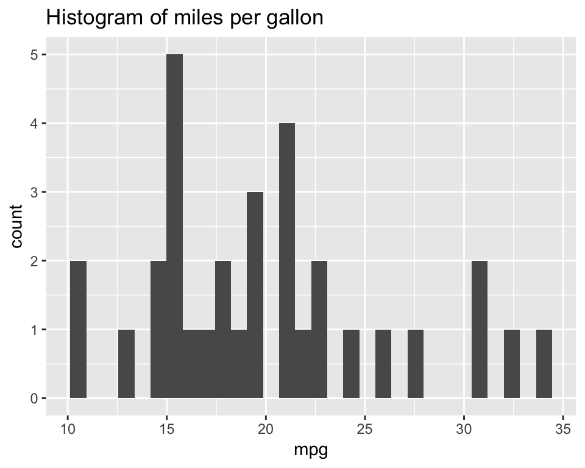

```r
ggplot(data = mtcars) +
    geom_histogram(aes(x = mpg)) +
    ggtitle("Histogram of miles per gallon")
```

## Scatterplots: continuous variable vs. continuous variable

*What is the relationship between `mpg` and `weight`?*

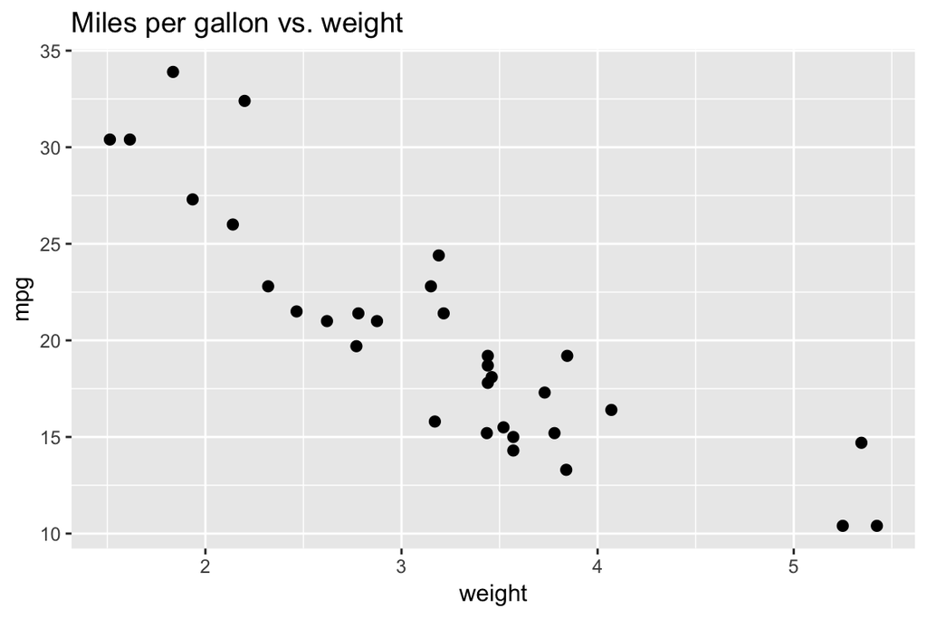

```r
ggplot(data = df) +
    geom_point(mapping = aes(y = mpg, x = weight), size = 2) +
    ggtitle("Miles per gallon vs. weight")
```

## Lineplots: continuous variable vs. time variable

*What is the relationship between `mpg` and time?*

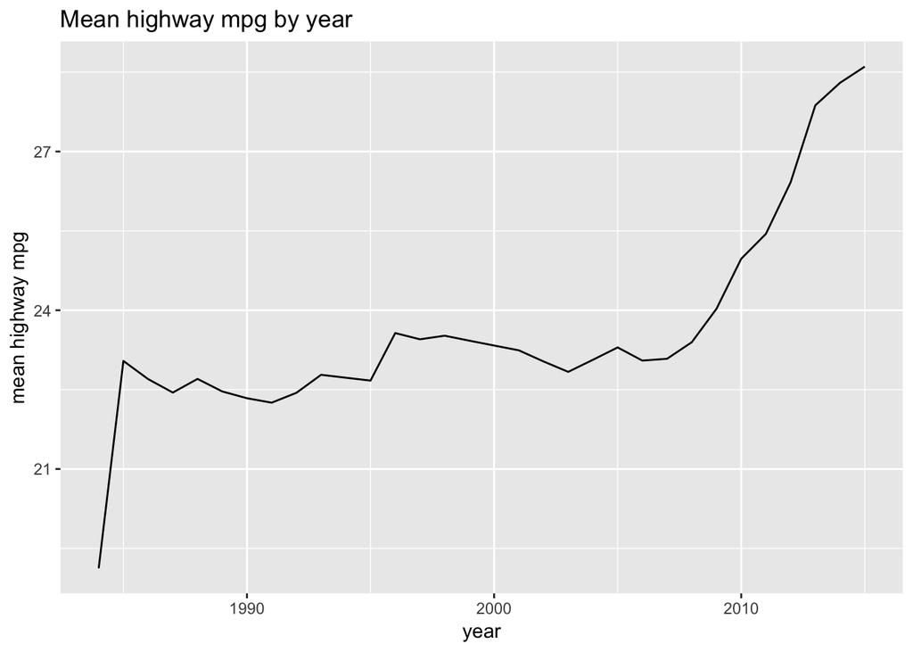

## Boxplots

*For each value of cylinder, what is the distribution of `mpg` like?*

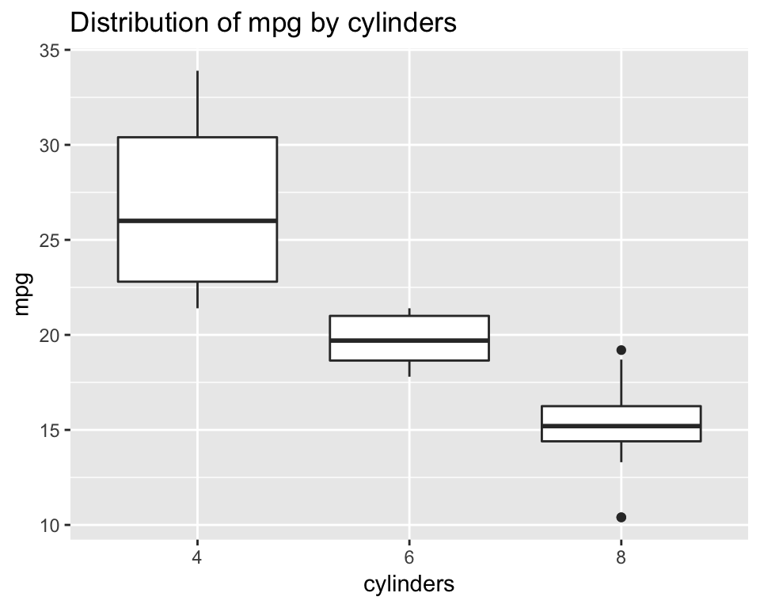

```r
ggplot(data = df) +
    geom_boxplot(aes(cylinders,mpg)) +
    ggtitle("Distribution of mpg by cylinders")
```

## Violinplots

*For each value of cylinder, what is the distribution of `mpg` like?*

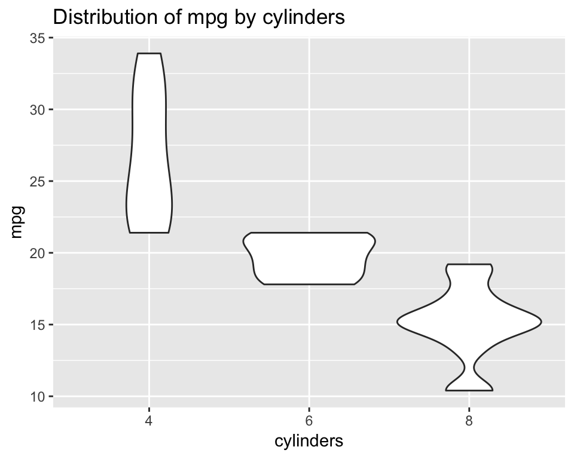

```r
ggplot(data = df) +
    geom_violin(aes(cylinders,mpg)) +
    ggtitle("Distribution of mpg by cylinders")
```

## Heatmaps: categorical variable vs. categorical variable

*How often does each pair of `cylinder` and `gear` occur in the dataset?*

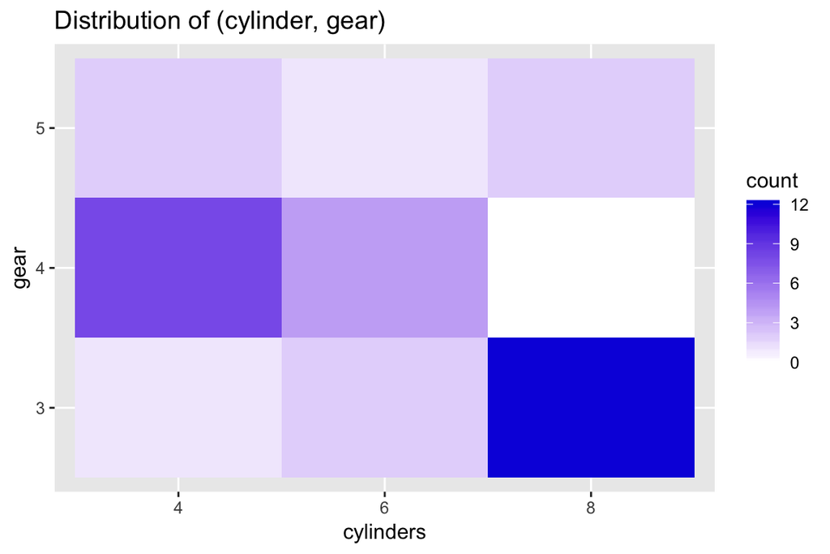

## Summary

- 1 categorical variable: barplot
- 1 continuous variable: histogram
- Continuous vs. continuous: scatterplot
- Continuous vs. time: lineplot
- Continuous vs. categorical: boxplots & violin plots
- Categorical vs. categorical: heatmap

## Data visualization in R: 2 broad approaches

### base R

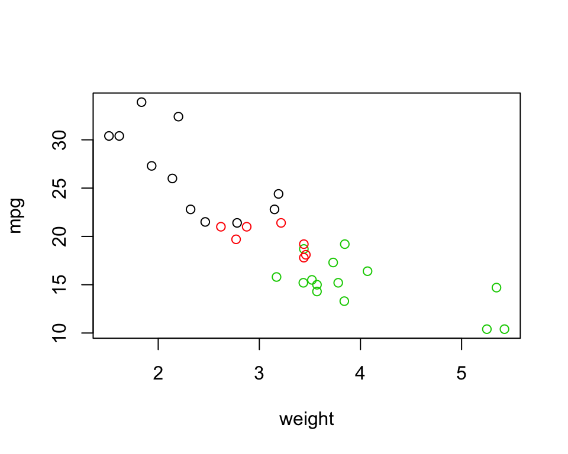

## Data visualization in R: 2 broad approaches

### `ggplot2`

## 3 essential elements of graphics: data, geometries, aesthetics

**Data**: Dataset we are using for the plot

```
##     mpg weight cylinders
## 1  21.0  2.620         6
## 2  21.0  2.875         6
## 3  22.8  2.320         4
## 4  21.4  3.215         6
## 5  18.7  3.440         8
## 6  18.1  3.460         6
## 7  14.3  3.570         8
## 8  24.4  3.190         4
## 9  22.8  3.150         4
## 10 19.2  3.440         6
```

## 3 essential elements of graphics: data, geometries, aesthetics

**Geom**etries: Visual elements used for our data

- E.g. point, line, histogram, bar, boxplot

Geom: point

## 3 essential elements of graphics: data, geometries, aesthetics

**Aes**thetics: Defines the data columns which affect various aspects of the geom

- E.g. x, y, color, fill, size, alpha, line type, line width
- Which **aes**thetics you use depend on the **geom**etries you choose

3 different aesthetics:

- x-axis: weight
- y-axis: mpg
- color: cylinders
- shape, size, etc. take on default values, not determined by data

## Examples of other aesthetics

- x-axis: weight
- y-axis: mpg
- size: cylinders
- alpha: weight

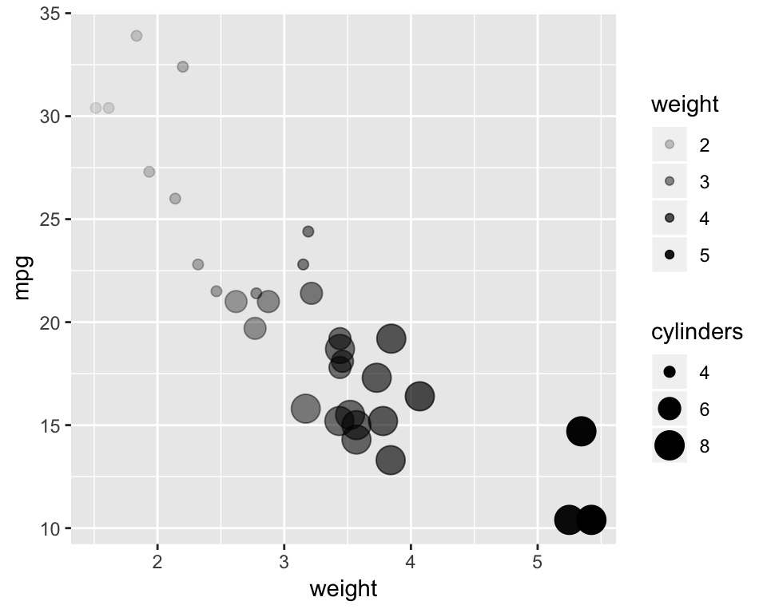

```r
p_base + geom_point(aes(size = cylinders, alpha = weight))
```

## Examples of other aesthetics

- x-axis: weight
- y-axis: mpg
- color: cylinders
- shape: cylinders

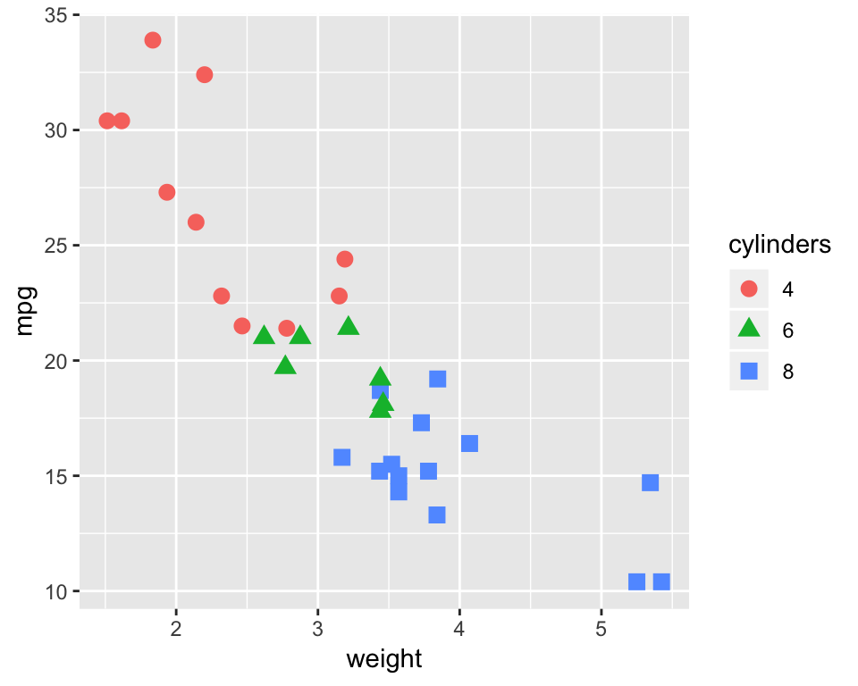

```r
p_base + geom_point(aes(col = cylinders, shape=cylinders), size = 3)
```

## `ggplot2` code

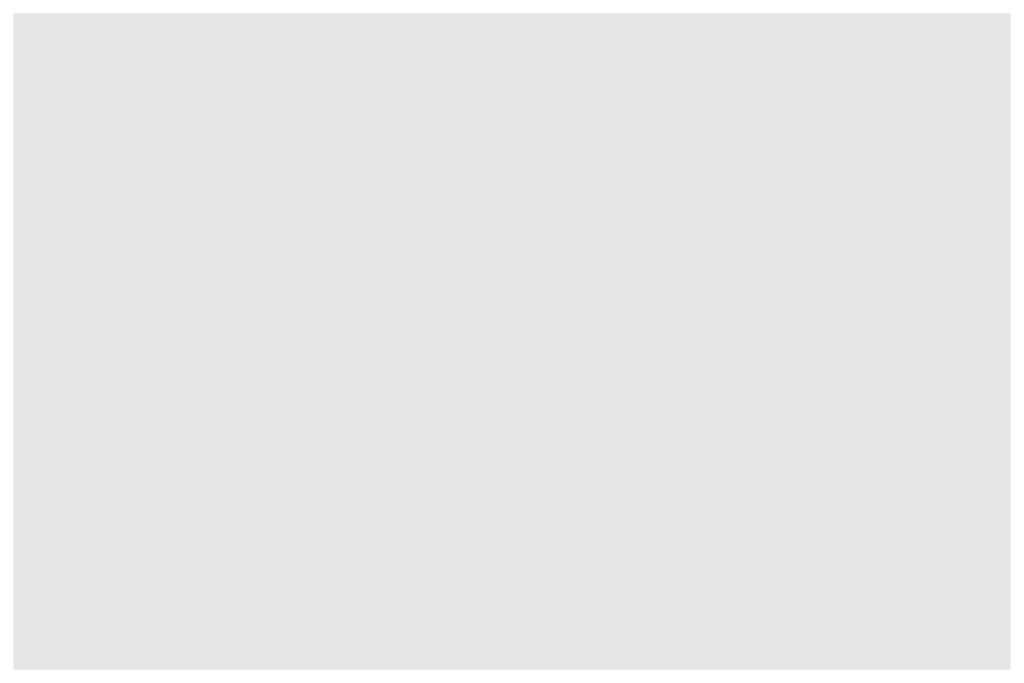

```r
ggplot()
```

## `ggplot2` code

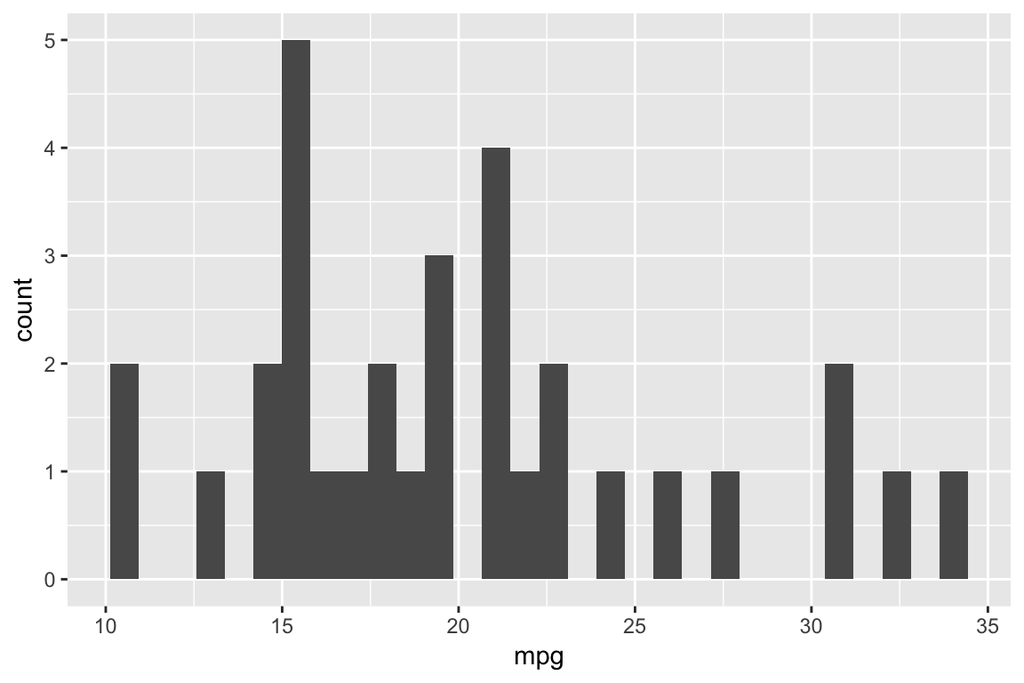

```r
ggplot() +
    geom_histogram(data = df, mapping = aes(x = mpg))
```

## `ggplot2` code

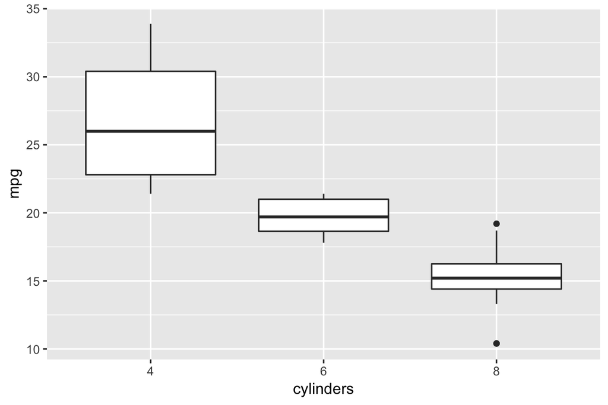

```r
ggplot() +
    geom_boxplot(data = df, mapping = aes(x = cylinders, y = mpg))
```

## `ggplot2` code

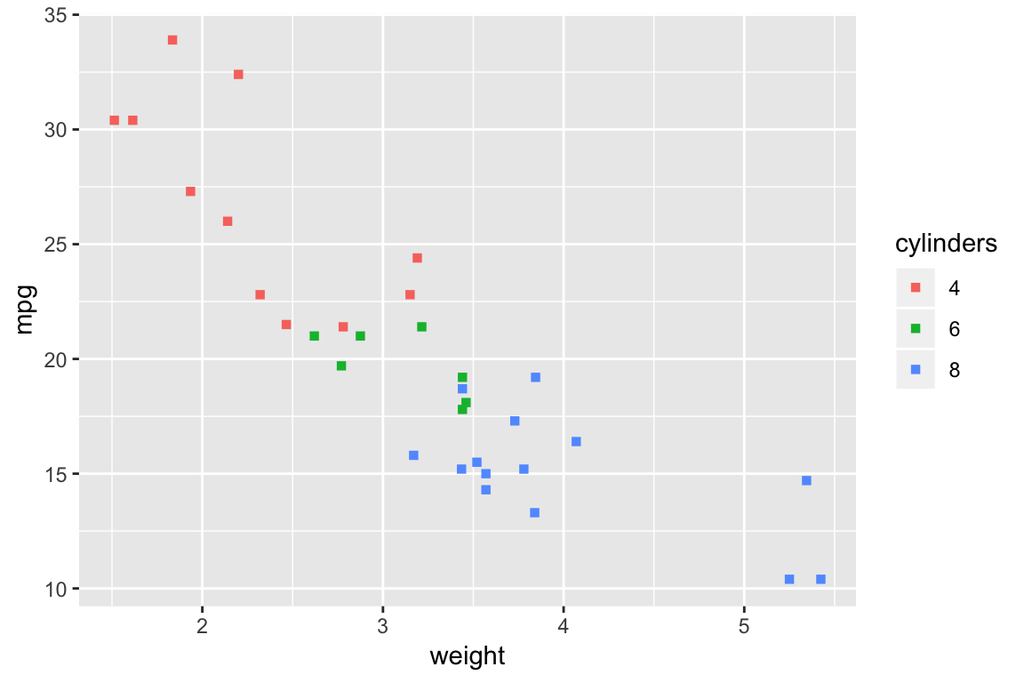

```r
ggplot() +
    geom_point(data = df,
               mapping = aes(x = weight, y = mpg, col = cylinders),
               shape = 15)
```

## Layers: Combining multiple plots into one graphic

We can have more than one **layer** in a graphic.

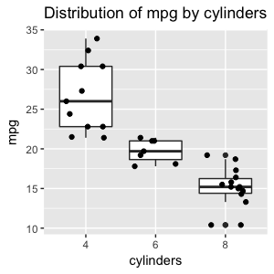

**=**

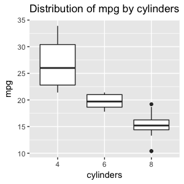

**+**

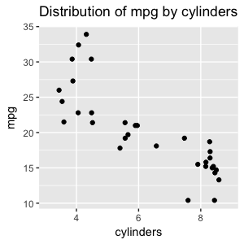

Each layer contains (essentially):

- 1 dataset, 1 **geom**etric object, **aes**thetic mappings

## `ggplot2` code

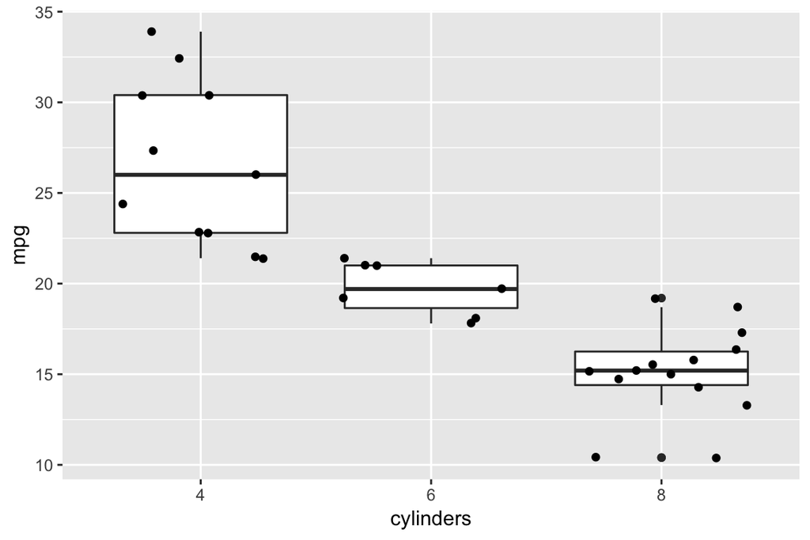

```r
ggplot() +
    geom_boxplot(data = df, mapping = aes(x = cylinders, y = mpg)) +
    geom_point(data = df, mapping = aes(x = cylinders, y = mpg),
               position = "jitter")
```

## `ggplot2` code

When layers share attributes, we only have to type them once:

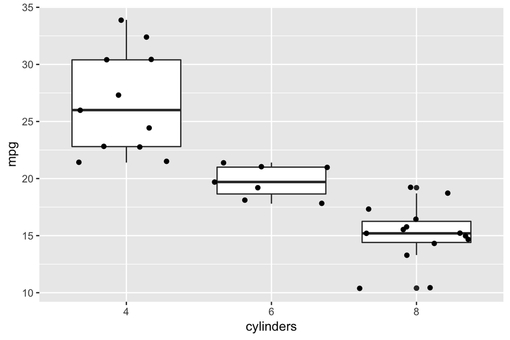

```r
ggplot(data = df, mapping = aes(x = cylinders, y = mpg)) +
    geom_boxplot() +
    geom_point(position = "jitter")
```

## `ggplot2` code

- We can drop `data =` if it is the first argument of `ggplot()`
- We can drop `mapping =` if:
  - it is the second argument of `ggplot()`
  - it is the first argument of a `geom_xx()` function

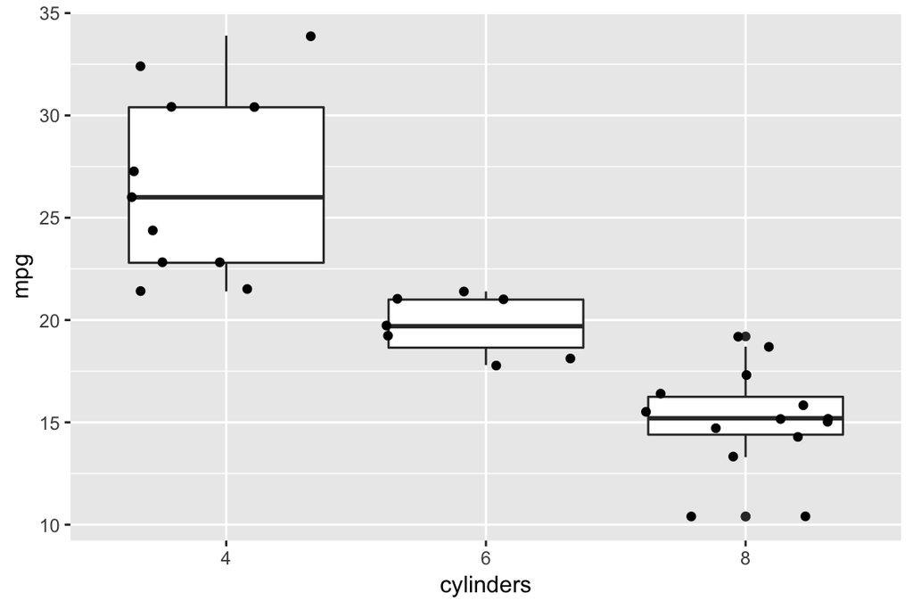

```r
ggplot(df, aes(x = cylinders, y = mpg)) +
    geom_boxplot() +
    geom_point(position = "jitter")
```

## Scales

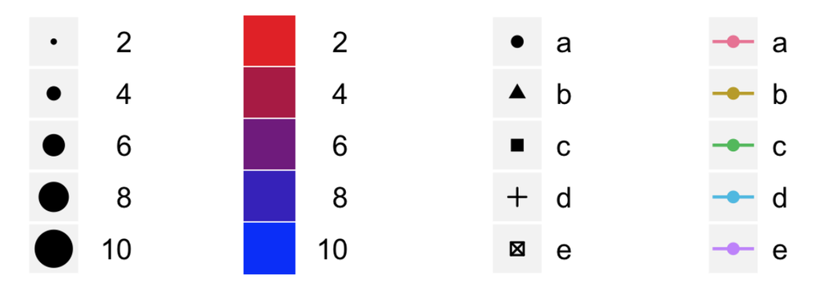

Examples of scales (Source: [A Layered Grammar of Graphics](http://vita.had.co.nz/papers/layered-grammar.pdf))

## Scales example: colors

**Manually chosen colors**

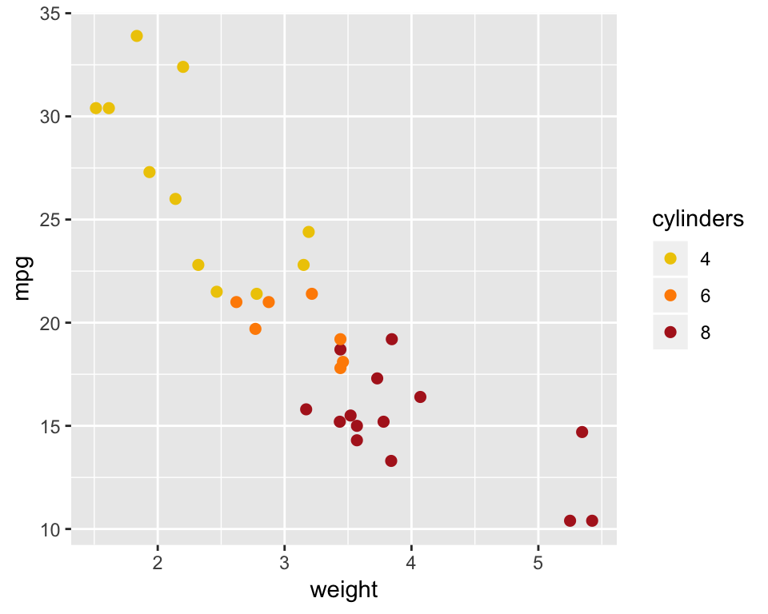

```r
p_scatter + scale_color_manual(values=c("gold2", "darkorange","firebrick"))
```

## Facets

- Plotting different parts of our data on different canvases
- Can give a clearer, less cluttered picture
- We can facet by rows and/or columns

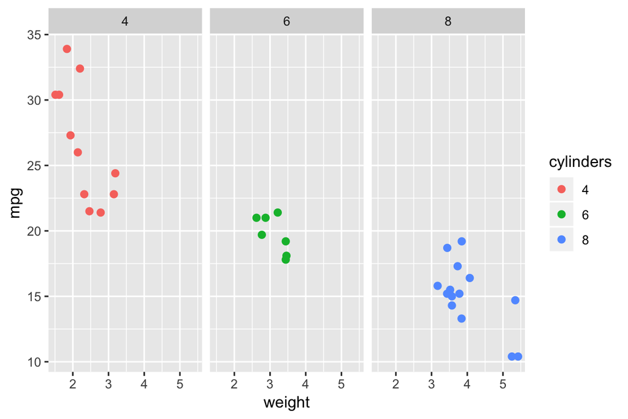

```r
p_scatter + facet_wrap(~cylinders)
```

## Themes

Refers to all non-data ink

- Titles, axis ticks & labels, background color, legend, etc.
- Can manually set each item, or use preset themes

**`ggplot2`’s default theme**

```r
p_scatter
```

[output not shown]

**Minimal theme**

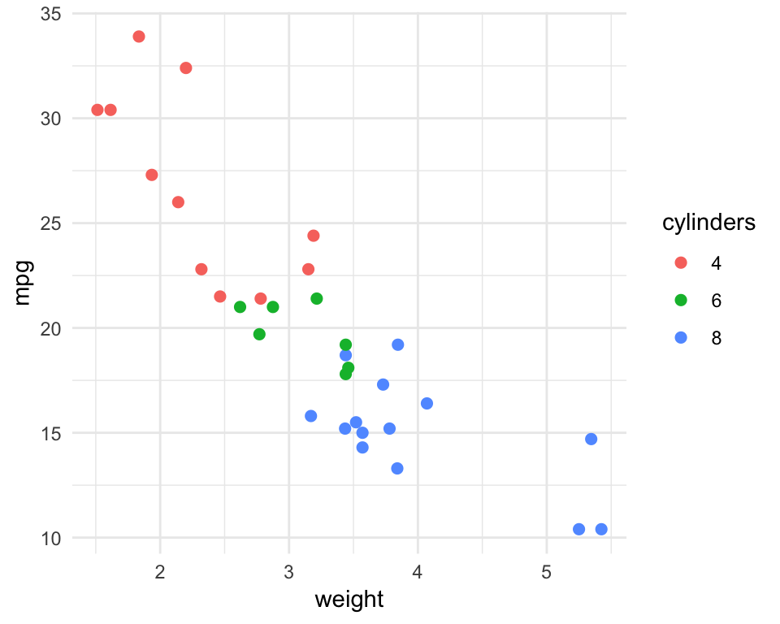

```r
p_scatter + theme_minimal()
```

## More pre-set themes

**Classic theme**

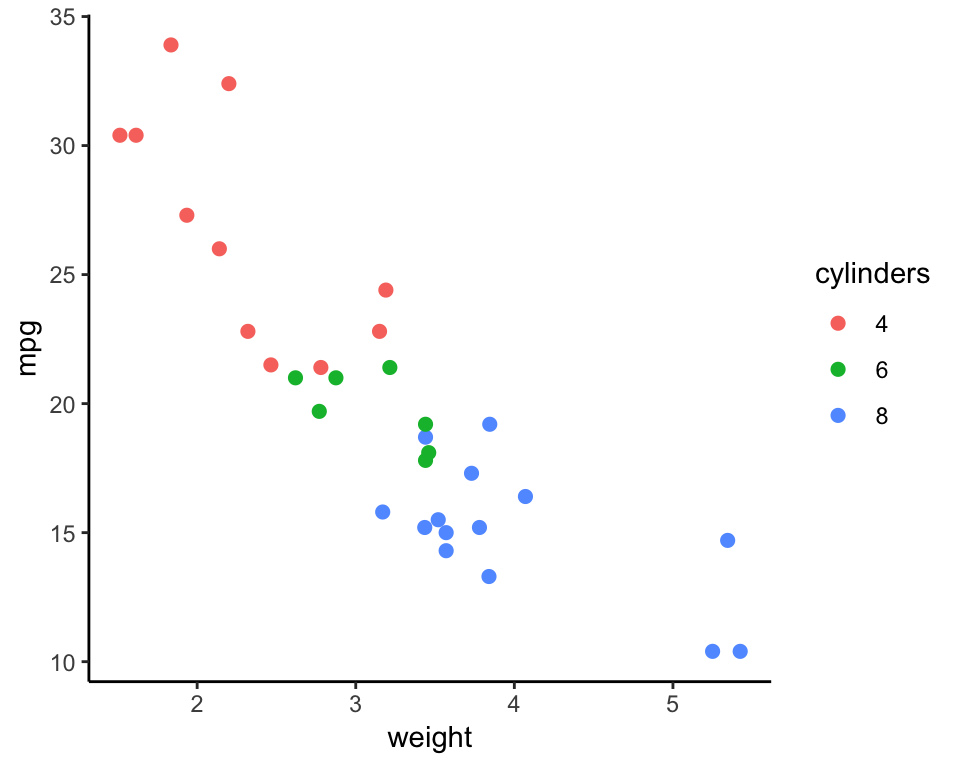

```r
p_scatter + theme_classic()
```

## More pre-set themes

**Dark theme**

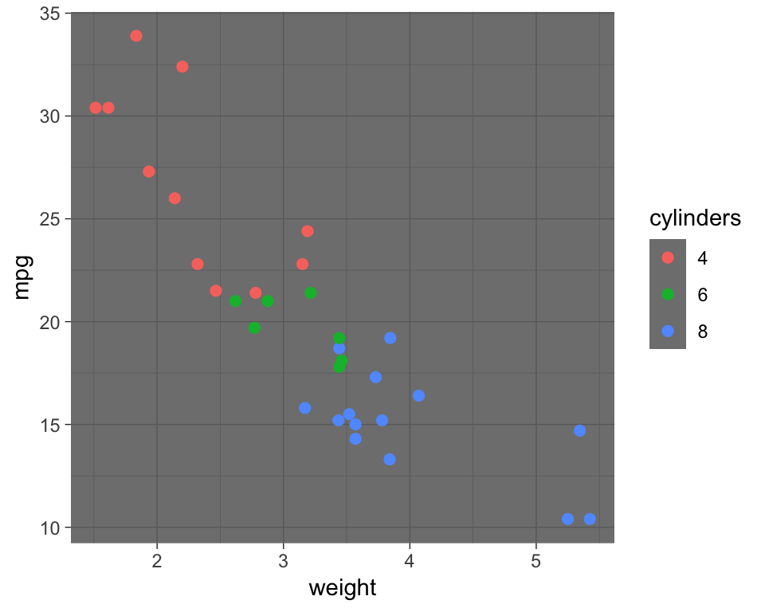

```r
p_scatter + theme_dark()
```

## We’ve only scratched the surface!

[R Graph Gallery](https://www.r-graph-gallery.com/): an excellent source of inspiration and code snippet examples